# Project

## Investigate a Dataset: The Movie Database (TMDB)

- Introduction
- Data Wrangling
- Exploratory Data Analysis
- Conclusions

## Introduction

> For this project, The Movie Database (TMDB) dataset will be investigated for insights and relationship. TMDB is a popular user editable database for movies and TV shows. It contains information and statistics about movies, actors, directors as well as other film industry professionals. This dataset has movies details such as revenue, budget, genres, popularity, etc. all contained in it.

### Questions for Analysis

- Which movie has the minimum and maximum Budget?
- Which movie generate the minimum and maximum Revenue?
- Which movie generate the minimum and maximum Profit?
- Which movie has the highest and lowest Popularity Score?
- Which movie has the highest and lowest Vote Average?
- Which is the most produced Genres?
- What is the budget over the Years?
- What is the revenue over the Years?
- Relationship within the dataset
- Budget & Revenue.
- Revenue & Profit.
- Popularity & Runtime.
- Popularity & Profit.
- Profit & Vote Count.
- Profit & Vote Average.
- Popularity & Vote Count.
- Popularity & Vote Average.
- Vote Count & Vote Average.
- How is the vote average of movies?.
- How is the runtime of movies?.

```python
# Loading packages for the analysis

import matplotlib.pyplot as plt
import numpy as np
import pandas as pd
import seaborn as sns
%matplotlib inline

# setting all plot backgound to darkgrid
sns.set_style('darkgrid')
```

## Data Wrangling

### General Properties

```python
# Assessing the database
ori_df = pd.read_csv('tmdb-movies.csv')

# Viewing the data
ori_df.head(3)
```

|  | id | imdb_id | popularity | budget | revenue | original_title | cast | homepage | director | tagline | ... | overview | runtime | genres | production_companies | release_date | vote_count | vote_average | release_year | budget_adj | revenue_adj |
| --- | --- | --- | --- | --- | --- | --- | --- | --- | --- | --- | --- | --- | --- | --- | --- | --- | --- | --- | --- | --- | --- |
| 0 | 135397 | tt0369610 | 32.985763 | 150000000 | 1513528810 | Jurassic World | Chris Pratt\|Bryce Dallas Howard\|Irrfan Khan\|Vi... | http://www.jurassicworld.com/ | Colin Trevorrow | The park is open. | ... | Twenty-two years after the events of Jurassic ... | 124 | Action\|Adventure\|Science Fiction\|Thriller | Universal Studios\|Amblin Entertainment\|Legenda... | 6/9/15 | 5562 | 6.5 | 2015 | 1.379999e+08 | 1.392446e+09 |
| 1 | 76341 | tt1392190 | 28.419936 | 150000000 | 378436354 | Mad Max: Fury Road | Tom Hardy\|Charlize Theron\|Hugh Keays-Byrne\|Nic... | http://www.madmaxmovie.com/ | George Miller | What a Lovely Day. | ... | An apocalyptic story set in the furthest reach... | 120 | Action\|Adventure\|Science Fiction\|Thriller | Village Roadshow Pictures\|Kennedy Miller Produ... | 5/13/15 | 6185 | 7.1 | 2015 | 1.379999e+08 | 3.481613e+08 |
| 2 | 262500 | tt2908446 | 13.112507 | 110000000 | 295238201 | Insurgent | Shailene Woodley\|Theo James\|Kate Winslet\|Ansel... | http://www.thedivergentseries.movie/#insurgent | Robert Schwentke | One Choice Can Destroy You | ... | Beatrice Prior must confront her inner demons ... | 119 | Adventure\|Science Fiction\|Thriller | Summit Entertainment\|Mandeville Films\|Red Wago... | 3/18/15 | 2480 | 6.3 | 2015 | 1.012000e+08 | 2.716190e+08 |

3 rows × 21 columns

#### Currency Choice

> Well, as we can see from the dataframe, there's no currency. Hence, for our analysis we will assume it to be in **Dollars ($)**.

#### Numerical Column Properties

```python
# Looking at the general properties of all numerical columns in the database.
ori_df.describe()
```

|  | id | popularity | budget | revenue | runtime | vote_count | vote_average | release_year | budget_adj | revenue_adj |
| --- | --- | --- | --- | --- | --- | --- | --- | --- | --- | --- |
| count | 10866.000000 | 10866.000000 | 1.086600e+04 | 1.086600e+04 | 10866.000000 | 10866.000000 | 10866.000000 | 10866.000000 | 1.086600e+04 | 1.086600e+04 |
| mean | 66064.177434 | 0.646441 | 1.462570e+07 | 3.982332e+07 | 102.070863 | 217.389748 | 5.974922 | 2001.322658 | 1.755104e+07 | 5.136436e+07 |
| std | 92130.136561 | 1.000185 | 3.091321e+07 | 1.170035e+08 | 31.381405 | 575.619058 | 0.935142 | 12.812941 | 3.430616e+07 | 1.446325e+08 |
| min | 5.000000 | 0.000065 | 0.000000e+00 | 0.000000e+00 | 0.000000 | 10.000000 | 1.500000 | 1960.000000 | 0.000000e+00 | 0.000000e+00 |
| 25% | 10596.250000 | 0.207583 | 0.000000e+00 | 0.000000e+00 | 90.000000 | 17.000000 | 5.400000 | 1995.000000 | 0.000000e+00 | 0.000000e+00 |
| 50% | 20669.000000 | 0.383856 | 0.000000e+00 | 0.000000e+00 | 99.000000 | 38.000000 | 6.000000 | 2006.000000 | 0.000000e+00 | 0.000000e+00 |
| 75% | 75610.000000 | 0.713817 | 1.500000e+07 | 2.400000e+07 | 111.000000 | 145.750000 | 6.600000 | 2011.000000 | 2.085325e+07 | 3.369710e+07 |
| max | 417859.000000 | 32.985763 | 4.250000e+08 | 2.781506e+09 | 900.000000 | 9767.000000 | 9.200000 | 2015.000000 | 4.250000e+08 | 2.827124e+09 |

> Looking at the result above, we can see that half of the revenue and budget column is filled with zeros.

#### Columns Data type

> We will look at the data type of each columnn

```python
# Columns data type
ori_df.dtypes
```

```
id                        int64
imdb_id                  object
popularity              float64
budget                    int64
revenue                   int64
original_title           object
cast                     object
homepage                 object
director                 object
tagline                  object
keywords                 object
overview                 object
runtime                   int64
genres                   object
production_companies     object
release_date             object
vote_count                int64
vote_average            float64
release_year              int64
budget_adj              float64
revenue_adj             float64
dtype: object
```

> From above, we can see that the release date is an object (str) datatype.

#### Checking for duplicates

> Let's look for duplicates in the database.

```python
# Bringing out rows that are duplicates
ori_df[ori_df.duplicated()]
```

|  | id | imdb_id | popularity | budget | revenue | original_title | cast | homepage | director | tagline | ... | overview | runtime | genres | production_companies | release_date | vote_count | vote_average | release_year | budget_adj | revenue_adj |
| --- | --- | --- | --- | --- | --- | --- | --- | --- | --- | --- | --- | --- | --- | --- | --- | --- | --- | --- | --- | --- | --- |
| 2090 | 42194 | tt0411951 | 0.59643 | 30000000 | 967000 | TEKKEN | Jon Foo\|Kelly Overton\|Cary-Hiroyuki Tagawa\|Ian... | NaN | Dwight H. Little | Survival is no game | ... | In the year of 2039, after World Wars destroy ... | 92 | Crime\|Drama\|Action\|Thriller\|Science Fiction | Namco\|Light Song Films | 3/20/10 | 110 | 5.0 | 2010 | 30000000.0 | 967000.0 |

1 rows × 21 columns

> Since we are having one duplicate, let's see both row that are duplicate and confirm that both contents are the same.

```python
# Searching for the other duplicate with the id from the above duplicate
ori_df[ori_df['id'] == 42194]
```

|  | id | imdb_id | popularity | budget | revenue | original_title | cast | homepage | director | tagline | ... | overview | runtime | genres | production_companies | release_date | vote_count | vote_average | release_year | budget_adj | revenue_adj |
| --- | --- | --- | --- | --- | --- | --- | --- | --- | --- | --- | --- | --- | --- | --- | --- | --- | --- | --- | --- | --- | --- |
| 2089 | 42194 | tt0411951 | 0.59643 | 30000000 | 967000 | TEKKEN | Jon Foo\|Kelly Overton\|Cary-Hiroyuki Tagawa\|Ian... | NaN | Dwight H. Little | Survival is no game | ... | In the year of 2039, after World Wars destroy ... | 92 | Crime\|Drama\|Action\|Thriller\|Science Fiction | Namco\|Light Song Films | 3/20/10 | 110 | 5.0 | 2010 | 30000000.0 | 967000.0 |
| 2090 | 42194 | tt0411951 | 0.59643 | 30000000 | 967000 | TEKKEN | Jon Foo\|Kelly Overton\|Cary-Hiroyuki Tagawa\|Ian... | NaN | Dwight H. Little | Survival is no game | ... | In the year of 2039, after World Wars destroy ... | 92 | Crime\|Drama\|Action\|Thriller\|Science Fiction | Namco\|Light Song Films | 3/20/10 | 110 | 5.0 | 2010 | 30000000.0 | 967000.0 |

2 rows × 21 columns

> Both content of the rows above are the same.

#### Looking at the database general information

```python
# Database information
ori_df.info()
```

```
<class 'pandas.core.frame.DataFrame'>
RangeIndex: 10866 entries, 0 to 10865
Data columns (total 21 columns):
id                      10866 non-null int64
imdb_id                 10856 non-null object
popularity              10866 non-null float64
budget                  10866 non-null int64
revenue                 10866 non-null int64
original_title          10866 non-null object
cast                    10790 non-null object
homepage                2936 non-null object
director                10822 non-null object
tagline                 8042 non-null object
keywords                9373 non-null object
overview                10862 non-null object
runtime                 10866 non-null int64
genres                  10843 non-null object
production_companies    9836 non-null object
release_date            10866 non-null object
vote_count              10866 non-null int64
vote_average            10866 non-null float64
release_year            10866 non-null int64
budget_adj              10866 non-null float64
revenue_adj             10866 non-null float64
dtypes: float64(4), int64(6), object(11)
memory usage: 1.7+ MB
```

> Looking at the above result, there are some columns that are not needed for our analysis.

#### List of columns not needed for analysis

```python
# list of columns not needed for our analysis
Colm_lst =['id', 'imdb_id', 'homepage', 'tagline', 'keywords', 'overview', 'production_companies','budget_adj','revenue_adj']
```

> **After assessing the database, the following observaton was noted.**
> - Some columns are not needed for analysis.
> - Revenue and Budget columns has half of their rows filled with zero(s) (0).
> - Release data type is an object (str).
> - There are duplicate in the database.
> - Columns like genres, directors and cast has a pipe "|" in its row.

### Data Cleaning

> In this section, we will be working with the listed observation above to make the dataset ready for explorations. We will tackle them accordingly.

> **1. Remove columns that are not needed for analysis**

```python
# Creating a copy of the original dataframe

mov_df = ori_df.copy()

# removing columns
mov_df = mov_df.drop(Colm_lst, axis =1)

# Viewing the data
mov_df.head(2)
```

|  | popularity | budget | revenue | original_title | cast | director | runtime | genres | release_date | vote_count | vote_average | release_year |
| --- | --- | --- | --- | --- | --- | --- | --- | --- | --- | --- | --- | --- |
| 0 | 32.985763 | 150000000 | 1513528810 | Jurassic World | Chris Pratt\|Bryce Dallas Howard\|Irrfan Khan\|Vi... | Colin Trevorrow | 124 | Action\|Adventure\|Science Fiction\|Thriller | 6/9/15 | 5562 | 6.5 | 2015 |
| 1 | 28.419936 | 150000000 | 378436354 | Mad Max: Fury Road | Tom Hardy\|Charlize Theron\|Hugh Keays-Byrne\|Nic... | George Miller | 120 | Action\|Adventure\|Science Fiction\|Thriller | 5/13/15 | 6185 | 7.1 | 2015 |

> **2. Removing all rows with zeros from revenue and budget columns**

> We can achieve this by first, replacing all zeros (0) with numpy NaN, then dropping all the NaN.

```python
# Selecting rows with zero in budget column
mov_df_b = mov_df[mov_df['budget'] == 0]

# Selecting rows with zero in revenue column
mov_df_r = mov_df[mov_df['revenue'] == 0]

# Counting the number of rows in each columns
mov_df_b['budget'].count() , mov_df_r['revenue'].count()
```

```
(5696, 6016)
```

```python
# Putting both column in a list for operation
colm_lst = ['budget','revenue']

# Replacing the zero(s) with NaN
mov_df[colm_lst] = mov_df[colm_lst].replace(0,np.NaN)

# Droppping the NaN(s) in the original dataset
mov_df.dropna(subset=colm_lst, inplace=True)
```

```python
# Counting the number of rows with zero(s) in each column
mov_df_b = mov_df[mov_df['budget'] == 0]
mov_df_r = mov_df[mov_df['revenue'] == 0]
mov_df_b['budget'].count() , mov_df_r['revenue'].count()

# It shows zero, different from when we checked earlier. This means this problem has been resolved.
```

```
(0, 0)
```

> **3. Changing release_date data type from object (str) to date format**

```python
mov_df['release_date'] = pd.to_datetime(mov_df['release_date'])

# Confirming
type(mov_df['release_date'][0])
```

```
pandas._libs.tslibs.timestamps.Timestamp
```

> **4. Deleting duplicates from the dataframe**

```python
#dropping duplicates
mov_df.drop_duplicates(inplace=True)
mov_df.duplicated().sum() # confirming that there is no duplicate.
```

```
0
```

> **5. A function that can seperate a columns content that has a pipe "|" seperator within its rows.**

> The said function would return a count of values in that column.

```python
# Defining our function
def Val_count(colm):

    # joining the content of the column together with pipe "|" as a seperator
    join = mov_df[colm].str.cat(sep='|')

    # turning the above to a pandas series
    series = pd.Series(join.split('|'))

    # counting the value of the series
    count = series.value_counts()

    # returns the counts as result
    return count

# testing
Dir_count = Val_count('cast')
Dir_count.head()
```

```
Robert De Niro       52
Bruce Willis         46
Samuel L. Jackson    44
Nicolas Cage         43
Matt Damon           36
dtype: int64
```

> We've tackled the issue as listed earlier. We need a profit column for our analysis. This can be generated by subtracting the budget from revenue.

> **Profit Column**

> We need to check the data type of both revenue and budget.

```python
# Checking data type
type(mov_df.revenue[0]),type(mov_df.budget[0])
```

```
(numpy.float64, numpy.float64)
```

```python
# Both column are float, we will change it to int before creating the profit column
mov_df['revenue'] = mov_df['revenue'].astype(int)
mov_df['budget'] = mov_df['budget'].astype(int)

# Confirming that both column are of int type
mov_df['revenue'].dtype, mov_df['budget'].dtype
```

```
(dtype('int64'), dtype('int64'))
```

```python
# profit column
mov_df.insert(3, 'profit', mov_df['revenue'] - mov_df['budget'])

# Viewing the data
mov_df.head(2)
```

|  | popularity | budget | revenue | profit | original_title | cast | director | runtime | genres | release_date | vote_count | vote_average | release_year |
| --- | --- | --- | --- | --- | --- | --- | --- | --- | --- | --- | --- | --- | --- |
| 0 | 32.985763 | 150000000 | 1513528810 | 1363528810 | Jurassic World | Chris Pratt\|Bryce Dallas Howard\|Irrfan Khan\|Vi... | Colin Trevorrow | 124 | Action\|Adventure\|Science Fiction\|Thriller | 2015-06-09 | 5562 | 6.5 | 2015 |
| 1 | 28.419936 | 150000000 | 378436354 | 228436354 | Mad Max: Fury Road | Tom Hardy\|Charlize Theron\|Hugh Keays-Byrne\|Nic... | George Miller | 120 | Action\|Adventure\|Science Fiction\|Thriller | 2015-05-13 | 6185 | 7.1 | 2015 |

## Exploratory Data Analysis

### Movie with minimum and maximum Budget

> Let's create a function that will return a dataframe of maximum and minimum row of an int column concatenated together. This function will be used across different columns for details.

```python
# Defining our function
def max_min(colm):

    # storing max id
    idMax = mov_df[colm].idxmax()

    # storing min id
    idMin = mov_df[colm].idxmin()

     # bringing out ths max row
    Max = pd.DataFrame(mov_df.loc[idMax])

    # bringing out the min row
    Min = pd.DataFrame(mov_df.loc[idMin])

    # concatenating both row
    bth_row = pd.concat([Max,Min], axis =1)

    # returning both as result
    return bth_row
```

Now we have created the function, let's find the movie with the maximum and minimum budget.

```python
# maximunm and minimum budget
max_min('budget')
```

|  | 2244 | 2618 |
| --- | --- | --- |
| popularity | 0.25054 | 0.090186 |
| budget | 425000000 | 1 |
| revenue | 11087569 | 100 |
| profit | -413912431 | 99 |
| original_title | The Warrior's Way | Lost & Found |
| cast | Kate Bosworth\|Jang Dong-gun\|Geoffrey Rush\|Dann... | David Spade\|Sophie Marceau\|Ever Carradine\|Step... |
| director | Sngmoo Lee | Jeff Pollack |
| runtime | 100 | 95 |
| genres | Adventure\|Fantasy\|Action\|Western\|Thriller | Comedy\|Romance |
| release_date | 2010-12-02 00:00:00 | 1999-04-23 00:00:00 |
| vote_count | 74 | 14 |
| vote_average | 6.4 | 4.8 |
| release_year | 2010 | 1999 |

Intreesting! we can see here that the maximum budget is 425 million dollars, and the mimumum budget is 1 dollar.

### Movie with minimum and maximum Revenue

Now that we have discovered movies with maximum and minimum budget, let's use the funcion to find out movies with maximum and minimum revenue.

```python
# maximunm and minimum revenue
max_min('revenue')
```

|  | 1386 | 5067 |
| --- | --- | --- |
| popularity | 9.43277 | 0.462609 |
| budget | 237000000 | 6000000 |
| revenue | 2781505847 | 2 |
| profit | 2544505847 | -5999998 |
| original_title | Avatar | Shattered Glass |
| cast | Sam Worthington\|Zoe Saldana\|Sigourney Weaver\|S... | Hayden Christensen\|Peter Sarsgaard\|ChloÃ« Sevi... |
| director | James Cameron | Billy Ray |
| runtime | 162 | 94 |
| genres | Action\|Adventure\|Fantasy\|Science Fiction | Drama\|History |
| release_date | 2009-12-10 00:00:00 | 2003-11-14 00:00:00 |
| vote_count | 8458 | 46 |
| vote_average | 7.1 | 6.4 |
| release_year | 2009 | 2003 |

Here we can see that the movie **Avatar** generated the highest revenue while **Shattered Glass** generated the lowest revenue.

### Movie with minimum and maximum Profit

Let's go ahead to check movies with minimum and maximum profit.

```python
# maximunm and minimum profit
max_min('profit')
```

|  | 1386 | 2244 |
| --- | --- | --- |
| popularity | 9.43277 | 0.25054 |
| budget | 237000000 | 425000000 |
| revenue | 2781505847 | 11087569 |
| profit | 2544505847 | -413912431 |
| original_title | Avatar | The Warrior's Way |
| cast | Sam Worthington\|Zoe Saldana\|Sigourney Weaver\|S... | Kate Bosworth\|Jang Dong-gun\|Geoffrey Rush\|Dann... |
| director | James Cameron | Sngmoo Lee |
| runtime | 162 | 100 |
| genres | Action\|Adventure\|Fantasy\|Science Fiction | Adventure\|Fantasy\|Action\|Western\|Thriller |
| release_date | 2009-12-10 00:00:00 | 2010-12-02 00:00:00 |
| vote_count | 8458 | 74 |
| vote_average | 7.1 | 6.4 |
| release_year | 2009 | 2010 |

Fascinating! **Avatar** which generated the bhighest revenue also generated the highest profit.

### Movie with highest and lowest Popularity Score

Popularity! Which movie has the highest popularity score? Let's find out.

```python
# Highest and Lowest popularity score
max_min('popularity')
```

|  | 0 | 7268 |
| --- | --- | --- |
| popularity | 32.9858 | 0.001117 |
| budget | 150000000 | 350000 |
| revenue | 1513528810 | 3515061 |
| profit | 1363528810 | 3165061 |
| original_title | Jurassic World | Born into Brothels |
| cast | Chris Pratt\|Bryce Dallas Howard\|Irrfan Khan\|Vi... | Zana Briski\|Avijit\|Geeta Masi\|Kochi\|Mamuni |
| director | Colin Trevorrow | Zana Briski\|Ross Kauffman |
| runtime | 124 | 85 |
| genres | Action\|Adventure\|Science Fiction\|Thriller | Documentary |
| release_date | 2015-06-09 00:00:00 | 2004-12-08 00:00:00 |
| vote_count | 5562 | 23 |
| vote_average | 6.5 | 6.4 |
| release_year | 2015 | 2004 |

The movie with highest popularity score is **Jurassic World**. Does it being popular mean it's as a result of the vote avaerage? Lets find out.

### Movie with highest and lowest Vote Average

Getting movie with highest and lowest vote average.

```python
# highest and lowest vote average
max_min('vote_average')
```

|  | 4178 | 4859 |
| --- | --- | --- |
| popularity | 7.19204 | 0.111351 |
| budget | 25000000 | 65000000 |
| revenue | 28341469 | 73706 |
| profit | 3341469 | -64926294 |
| original_title | The Shawshank Redemption | Foodfight! |
| cast | Tim Robbins\|Morgan Freeman\|Bob Gunton\|William ... | Charlie Sheen\|Wayne Brady\|Hilary Duff\|Eva Long... |
| director | Frank Darabont | Lawrence Kasanoff |
| runtime | 142 | 87 |
| genres | Drama\|Crime | Animation\|Action\|Comedy\|Family |
| release_date | 1994-09-10 00:00:00 | 2012-06-15 00:00:00 |
| vote_count | 5754 | 12 |
| vote_average | 8.4 | 2.2 |
| release_year | 1994 | 2012 |

It appears that the movie with the highest vote average is **The Shawshank Redemption**, not **Jurassic World** which has the highest popularity.

### Most produced Genres

Let's find the genre produced the most.

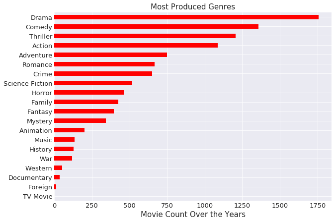

```python
# Using the function we created earlier
gnrs = Val_count('genres').sort_values()

# Plotting the most produced genres
mst_gnrs = gnrs.plot(kind='barh', figsize=(10,7), color='r')
mst_gnrs.set_title('Most Produced Genres', fontsize=15)
mst_gnrs.set_xlabel('Movie Count Over the Years', fontsize=15)
mst_gnrs.tick_params(labelsize=13)
```

Drama is interestingly the most produced genre, followed by comedy.

### Budget over the Years

We are about to find out movie with the highest budget over the years.

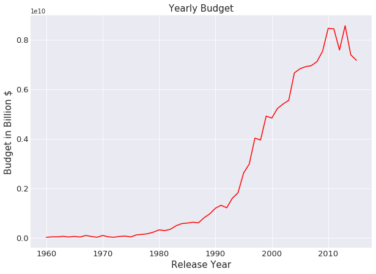

```python
# Plotting the yearly budget
grp_yr_b = mov_df.groupby('release_year')['budget'].sum()
yr_prt = grp_yr_b.plot(figsize=(10,7), color='r')
yr_prt.set_title('Yearly Budget', fontsize = 15)
yr_prt.set_xlabel('Release Year', fontsize=15)
yr_prt.set_ylabel('Budget in Billion $', fontsize=15)
yr_prt.tick_params(labelsize =13)
```

The Budget steadily increased over the decades, but it seems it is decreasing.

### Revenue over the Years

Let's check what the revenue has been over the years.

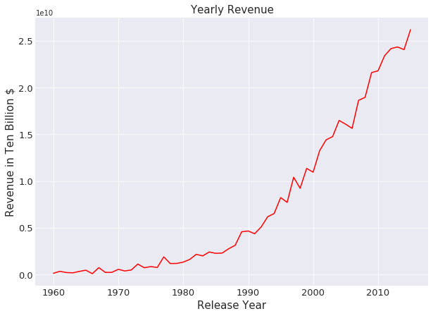

```python
# Plotting the yearly revenue
grp_yr_b = mov_df.groupby('release_year')['revenue'].sum()
yr_rvn = grp_yr_b.plot(figsize=(10,7), color='r')
yr_rvn.set_title('Yearly Revenue', fontsize = 15)
yr_rvn.set_xlabel('Release Year', fontsize=15)
yr_rvn.set_ylabel('Revenue in Ten Billion $', fontsize=15)
yr_rvn.tick_params(labelsize =13)
```

It appears that the revenue is inreasing over the year.

### Relationships within the dataset

Let's see how variables in the dataset relate with one another.

#### Budget & Revenue

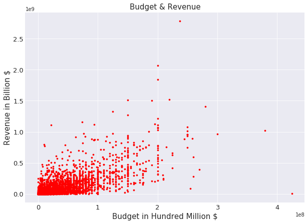

```python
# Showing relationship with scatter plot
bg_rvn = mov_df.plot.scatter(x='budget', y='revenue',c='r',figsize=(10,7),s=7,alpha=1)
bg_rvn.set_title('Budget & Revenue', fontsize=15)
bg_rvn.set_xlabel('Budget in Hundred Million $', fontsize=15)
bg_rvn.set_ylabel('Revenue in Billion $',fontsize=15)
bg_rvn.tick_params(labelsize=13);
```

#### Revenue & Profit

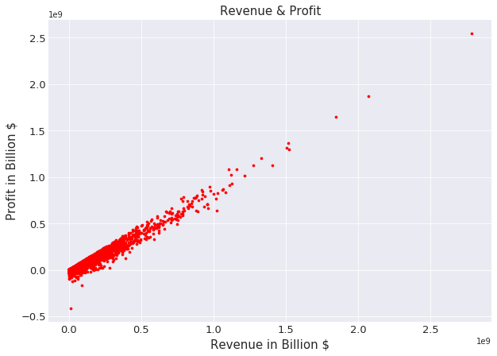

```python
# Showing relationship with scatter plot
bg_prt = mov_df.plot.scatter(x='revenue', y='profit',c='r',figsize=(10,7),s=7,alpha=1)
bg_prt.set_title('Revenue & Profit', fontsize=15)
bg_prt.set_xlabel('Revenue in Billion $', fontsize=15)
bg_prt.set_ylabel('Profit in Billion $',fontsize=15)
bg_prt.tick_params(labelsize=13);
```

As depicted by the plot, there is poitve relationship between revenue and provit. The higher the revenue, the higher the profit.

#### Popularity & Runtime

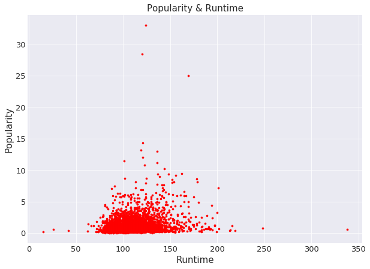

```python
# Showing relationship with scatter plot
pplrt_rtm = mov_df.plot.scatter(x='runtime', y='popularity',c='r',figsize=(10,7),s=7,alpha=1)
pplrt_rtm.set_title('Popularity & Runtime', fontsize=15)
pplrt_rtm.set_xlabel('Runtime', fontsize=15)
pplrt_rtm.set_ylabel('Popularity',fontsize=15)
pplrt_rtm.tick_params(labelsize=13);
```

As depicted by the plot, popularity of movies is not dependent on runtime.

#### Popularity & Profit

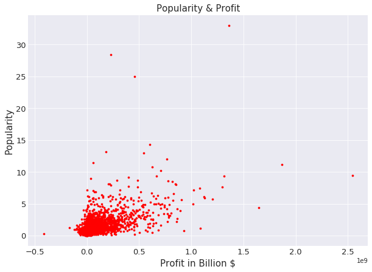

```python
# Showing relationship with scatter plot
pplrt_prt = mov_df.plot.scatter(x='profit', y='popularity',c='r',figsize=(10,7),s=7,alpha=1)
pplrt_prt.set_title('Popularity & Profit', fontsize=15)
pplrt_prt.set_xlabel('Profit in Billion $', fontsize=15)
pplrt_prt.set_ylabel('Popularity',fontsize=15)
pplrt_prt.tick_params(labelsize=13);
```

The highest profit is over 2.5 billion dollars, yet it doesn't have the highest popularity. Thus, popularity of movie doesn't depend on profit generated.

#### Profit & Vote Count

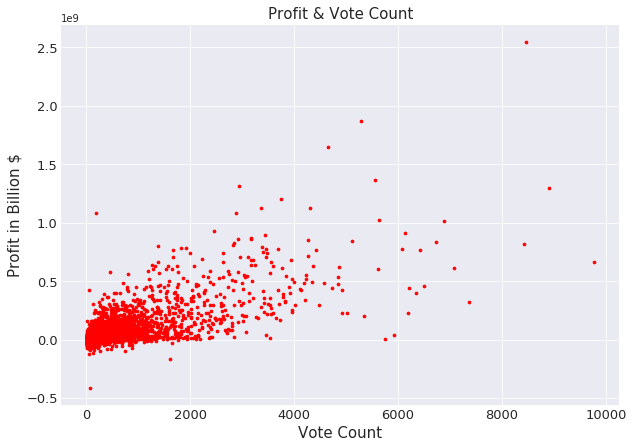

```python
# Showing relationship with scatter plot
prt_vct = mov_df.plot.scatter(x='vote_count', y='profit',c='r',figsize=(10,7),s=7,alpha=1)
prt_vct.set_title('Profit & Vote Count', fontsize=15)
prt_vct.set_xlabel('Vote Count', fontsize=15)
prt_vct.set_ylabel('Profit in Billion $',fontsize=15)
prt_vct.tick_params(labelsize=13);
```

Movie with high profit seem to also have high vote count.

#### Profit & Vote Average

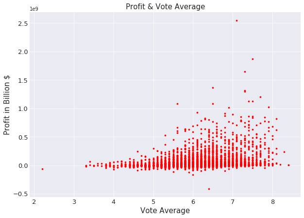

```python
# Showing relationship with scatter plot
prt_vavg = mov_df.plot.scatter(x='vote_average', y='profit',c='r',figsize=(10,7),s=7,alpha=1)
prt_vavg.set_title('Profit & Vote Average', fontsize=15)
prt_vavg.set_xlabel('Vote Average', fontsize=15)
prt_vavg.set_ylabel('Profit in Billion $',fontsize=15)
prt_vavg.tick_params(labelsize=13);
```

The highest profit has a vote average above 7.

#### Popularity & Vote Count

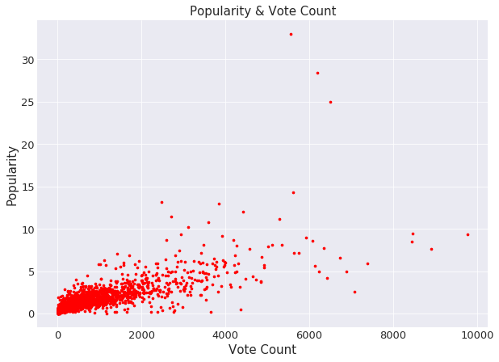

```python
# Showing relationship with scatter plot
pplrt_vct = mov_df.plot.scatter(x='vote_count', y='popularity',c='r',figsize=(10,7),s=7,alpha=1)
pplrt_vct.set_title('Popularity & Vote Count', fontsize=15)
pplrt_vct.set_xlabel('Vote Count', fontsize=15)
pplrt_vct.set_ylabel('Popularity',fontsize=15)
pplrt_vct.tick_params(labelsize=13);
```

#### Popularity & Vote Average

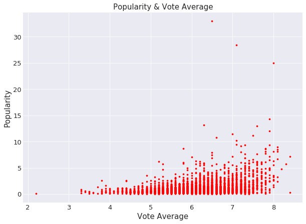

```python
# Showing relationship with scatter plot
pplrt_vavg = mov_df.plot.scatter(x='vote_average', y='popularity',c='r',figsize=(10,7),s=7,alpha=1)
pplrt_vavg.set_title('Popularity & Vote Average', fontsize=15)
pplrt_vavg.set_xlabel('Vote Average', fontsize=15)
pplrt_vavg.set_ylabel('Popularity',fontsize=15)
pplrt_vavg.tick_params(labelsize=13);
```

The higher the vote average, the higher the popularity.

#### Vote Average & Vote Count

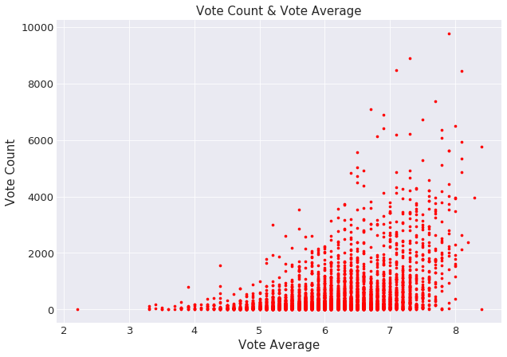

```python
# Showing relationship with scatter plot
pplrt_vct = mov_df.plot.scatter(x='vote_average', y='vote_count',c='r',figsize=(10,7),s=7,alpha=1)
pplrt_vct.set_title('Vote Count & Vote Average', fontsize=15)
pplrt_vct.set_xlabel('Vote Average', fontsize=15)
pplrt_vct.set_ylabel('Vote Count',fontsize=15)
pplrt_vct.tick_params(labelsize=13);
```

There is positive relationship between vote count and vote avaerage.

### How is the vote average of movies?

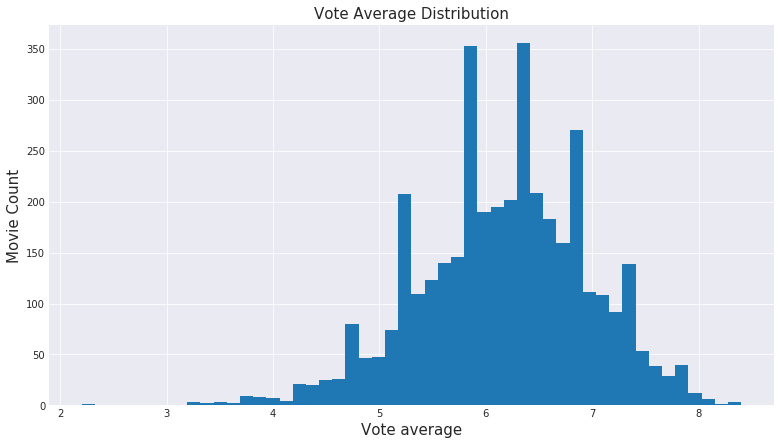

```python
# showing distribution with a histogram
vavg = mov_df['vote_average']
plt.figure(figsize=(13,7))
plt.hist(vavg,bins=50)
plt.title('Vote Average Distribution',fontsize=15)
plt.xlabel('Vote average', fontsize=15)
plt.ylabel('Movie Count', fontsize=15);
```

The high vote avaerage of movie fall between 5 and 7.

### How is the runtime of movies?

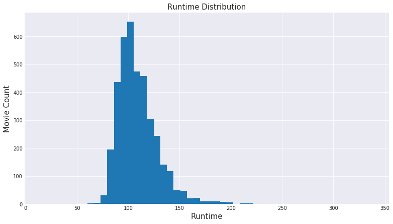

```python
# showing distribution with a histogram
rtm = mov_df['runtime']
plt.figure(figsize=(13,7))
plt.hist(rtm,bins=50)
plt.title('Runtime Distribution',fontsize=15)
plt.xlabel('Runtime', fontsize=15)
plt.ylabel('Movie Count', fontsize=15);
```

From the distribution above, runtime of movie is skewed to the right, and most of the movies has a runtime above 100 minutes.

## Conclusions

> **Limitation of the analysis**
> - The currency was not given so **Dollars ($)** was used. There's a high probability that most of the financial column could be in different currency, meaning it would affect our analysis result.
> - Also the rows dropped in the course of analysing this data is to be considered. For instance, the budget column, the rows we dropped because it had zero(s), some of it actually had values on the revenue column. Which means the movie with maximum and minimum revenue in our analysis above may or may not be true.